# Loan Data from Prosper by Gvantsa Mchedlidze

Presented Loan Data from Prosper with last updated 03/11/2014. This data set contains 113,937 loans with 81 variables on each loan.

```
## 'data.frame':    113937 obs. of  81 variables:
##  $ ListingKey                         : Factor w/ 113066 levels "00003546482094282EF90E5",..: 7180 7193 6647 6669 6686 6689 6699 6706 6687 6687 ...
##  $ ListingNumber                      : int  193129 1209647 81716 658116 909464 1074836 750899 768193 1023355 1023355 ...
##  $ ListingCreationDate                : Factor w/ 113064 levels "2005-11-09 20:44:28.847000000",..: 14184 111894 6429 64760 85967 100310 72556 74019 97834 97834 ...
##  $ CreditGrade                        : Factor w/ 9 levels "","A","AA","B",..: 5 1 8 1 1 1 1 1 1 1 ...
##  $ Term                               : int  36 36 36 36 36 60 36 36 36 36 ...
##  $ LoanStatus                         : Factor w/ 12 levels "Cancelled","Chargedoff",..: 3 4 3 4 4 4 4 4 4 4 ...
##  $ ClosedDate                         : Factor w/ 2803 levels "","2005-11-25 00:00:00",..: 1138 1 1263 1 1 1 1 1 1 1 ...
##  $ BorrowerAPR                        : num  0.165 0.12 0.283 0.125 0.246 ...
##  $ BorrowerRate                       : num  0.158 0.092 0.275 0.0974 0.2085 ...
##  $ LenderYield                        : num  0.138 0.082 0.24 0.0874 0.1985 ...
##  $ EstimatedEffectiveYield            : num  NA 0.0796 NA 0.0849 0.1832 ...
##  $ EstimatedLoss                      : num  NA 0.0249 NA 0.0249 0.0925 ...
##  $ EstimatedReturn                    : num  NA 0.0547 NA 0.06 0.0907 ...
##  $ ProsperRating..numeric.            : int  NA 6 NA 6 3 5 2 4 7 7 ...
```

[output cut: 67 more lines]

```
##                    ListingKey     ListingNumber
##  17A93590655669644DB4C06:     6   Min.   :      4
##  349D3587495831350F0F648:     4   1st Qu.: 400919
##  47C1359638497431975670B:     4   Median : 600554
##  8474358854651984137201C:     4   Mean   : 627886
##  DE8535960513435199406CE:     4   3rd Qu.: 892634
##  04C13599434217079754AEE:     3   Max.   :1255725
##  (Other)                :113912
##                     ListingCreationDate  CreditGrade         Term
##  2013-10-02 17:20:16.550000000:     6          :84984   Min.   :12.00
##  2013-08-28 20:31:41.107000000:     4   C      : 5649   1st Qu.:36.00
##  2013-09-08 09:27:44.853000000:     4   D      : 5153   Median :36.00
##  2013-12-06 05:43:13.830000000:     4   B      : 4389   Mean   :40.83
##  2013-12-06 11:44:58.283000000:     4   AA     : 3509   3rd Qu.:36.00
##  2013-08-21 07:25:22.360000000:     3   HR     : 3508   Max.   :60.00
##  (Other)                      :113912   (Other): 6745
##                  LoanStatus                  ClosedDate
##  Current              :56576                      :58848
##  Completed            :38074   2014-03-04 00:00:00:  105
##  Chargedoff           :11992   2014-02-19 00:00:00:  100
##  Defaulted            : 5018   2014-02-11 00:00:00:   92
##  Past Due (1-15 days) :  806   2012-10-30 00:00:00:   81
##  Past Due (31-60 days):  363   2013-02-26 00:00:00:   78
##  (Other)              : 1108   (Other)            :54633
##   BorrowerAPR       BorrowerRate     LenderYield
##  Min.   :0.00653   Min.   :0.0000   Min.   :-0.0100
##  1st Qu.:0.15629   1st Qu.:0.1340   1st Qu.: 0.1242
##  Median :0.20976   Median :0.1840   Median : 0.1730
##  Mean   :0.21883   Mean   :0.1928   Mean   : 0.1827
##  3rd Qu.:0.28381   3rd Qu.:0.2500   3rd Qu.: 0.2400
##  Max.   :0.51229   Max.   :0.4975   Max.   : 0.4925
##  NA's   :25
##  EstimatedEffectiveYield EstimatedLoss   EstimatedReturn
##  Min.   :-0.183          Min.   :0.005   Min.   :-0.183
##  1st Qu.: 0.116          1st Qu.:0.042   1st Qu.: 0.074
##  Median : 0.162          Median :0.072   Median : 0.092
##  Mean   : 0.169          Mean   :0.080   Mean   : 0.096
##  3rd Qu.: 0.224          3rd Qu.:0.112   3rd Qu.: 0.117
##  Max.   : 0.320          Max.   :0.366   Max.   : 0.284
##  NA's   :29084           NA's   :29084   NA's   :29084
```

[output cut: 193 more lines]

```
##  Min.   :    0.00                Min.   :0.7000   Min.   : 0.00000
##  1st Qu.:    0.00                1st Qu.:1.0000   1st Qu.: 0.00000
##  Median :    0.00                Median :1.0000   Median : 0.00000
##  Mean   :   25.14                Mean   :0.9986   Mean   : 0.04803
##  3rd Qu.:    0.00                3rd Qu.:1.0000   3rd Qu.: 0.00000
##  Max.   :21117.90                Max.   :1.0125   Max.   :39.00000
##
##  InvestmentFromFriendsCount InvestmentFromFriendsAmount   Investors
##  Min.   : 0.00000           Min.   :    0.00            Min.   :   1.00
##  1st Qu.: 0.00000           1st Qu.:    0.00            1st Qu.:   2.00
##  Median : 0.00000           Median :    0.00            Median :  44.00
##  Mean   : 0.02346           Mean   :   16.55            Mean   :  80.48
##  3rd Qu.: 0.00000           3rd Qu.:    0.00            3rd Qu.: 115.00
##  Max.   :33.00000           Max.   :25000.00            Max.   :1189.00
##
```

# Univariate Plots Section

The length of the loan expressed in months.

```
##    Min. 1st Qu.  Median    Mean 3rd Qu.    Max.
##   12.00   36.00   36.00   40.83   36.00   60.00
```

The current status of the loan: Cancelled, Chargedoff, Completed, Current, Defaulted, FinalPaymentInProgress, PastDue. The PastDue status will be accompanied by a delinquency bucket.

```
##              Cancelled             Chargedoff              Completed
##                      5                  11992                  38074
##                Current              Defaulted FinalPaymentInProgress
##                  56576                   5018                    205
##   Past Due (>120 days)   Past Due (1-15 days)  Past Due (16-30 days)
##                     16                    806                    265
##  Past Due (31-60 days)  Past Due (61-90 days) Past Due (91-120 days)
##                    363                    313                    304
```

The employment status of the borrower at the time they posted the listing.

```
##                    Employed     Full-time Not available  Not employed
##          2255         67322         26355          5347           835
##         Other     Part-time       Retired Self-employed
##          3806          1088           795          6134
```

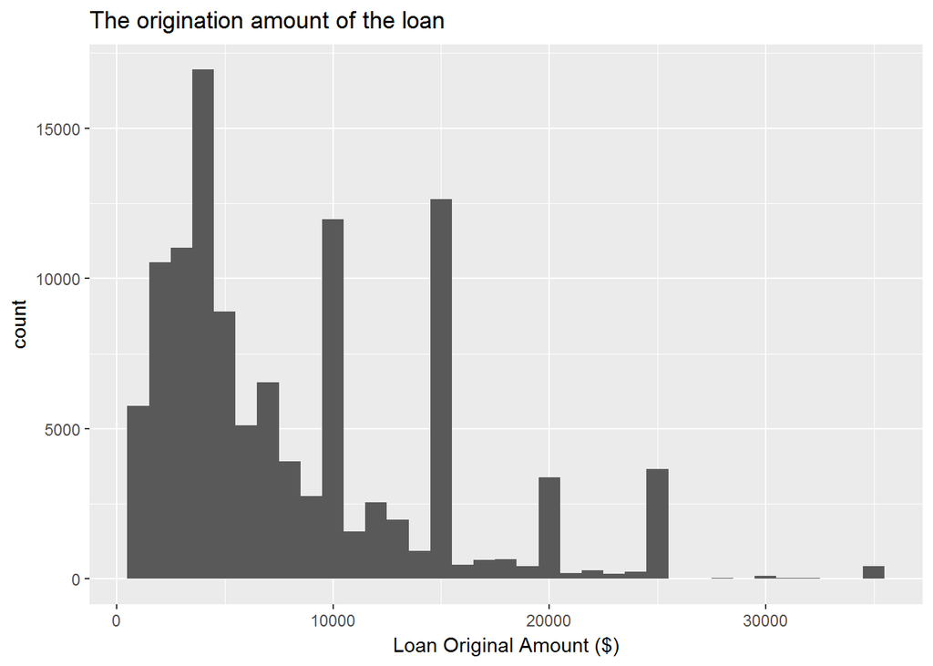

```
##    Min. 1st Qu.  Median    Mean 3rd Qu.    Max.
##    1000    4000    6500    8337   12000   35000
```

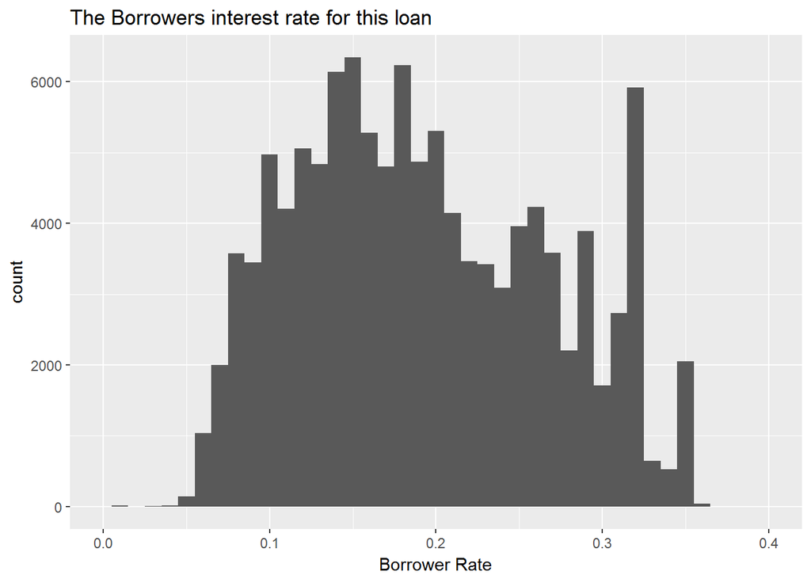

```
##    Min. 1st Qu.  Median    Mean 3rd Qu.    Max.
##  0.0000  0.1340  0.1840  0.1928  0.2500  0.4975
```

Lender yield is equal to the interest rate on the loan less the servicing fee.

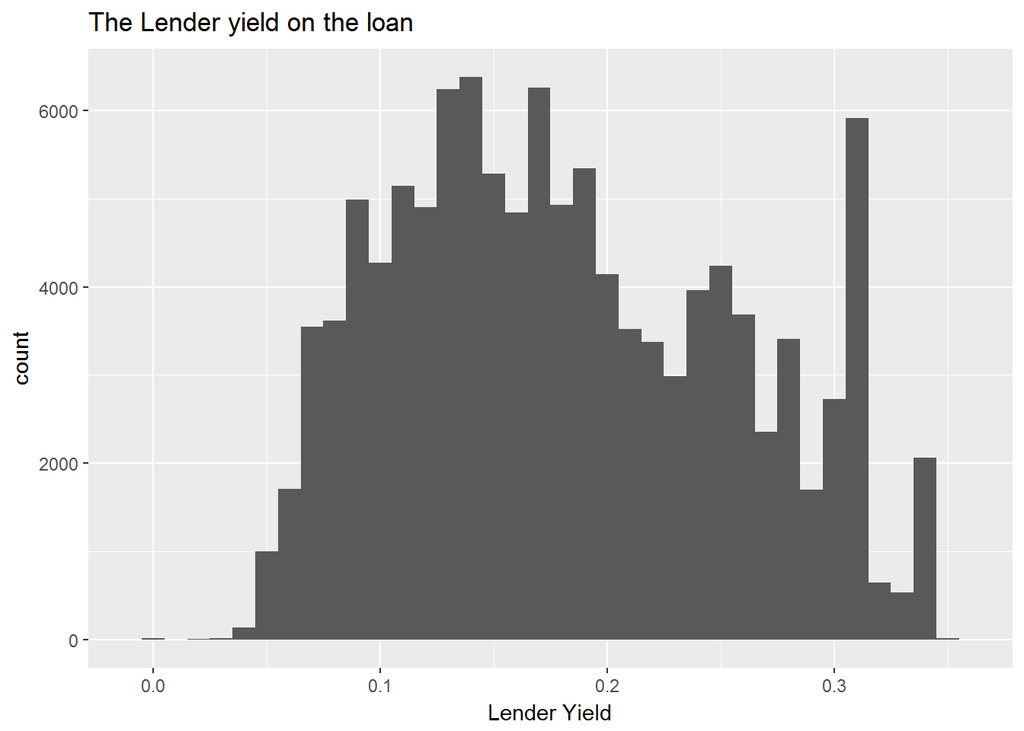

```
##    Min. 1st Qu.  Median    Mean 3rd Qu.    Max.
## -0.0100  0.1242  0.1730  0.1827  0.2400  0.4925
```

Effective yield is equal to the borrower interest rate (i) minus the servicing fee rate, (ii) minus estimated uncollected interest on charge-offs, (iii) plus estimated collected late fees. Applicable for loans originated after July 2009.

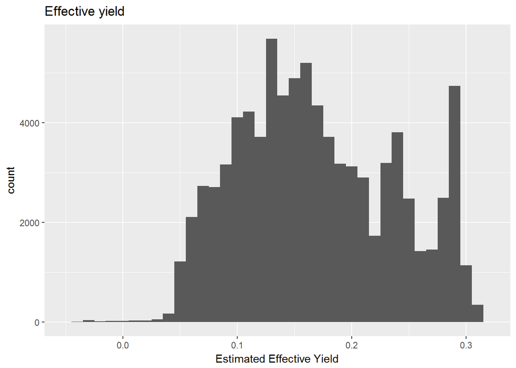

```
##    Min. 1st Qu.  Median    Mean 3rd Qu.    Max.    NA's
##  -0.183   0.116   0.162   0.169   0.224   0.320   29084
```

Estimated loss is the estimated principal loss on charge-offs. Applicable for loans originated after July 2009.

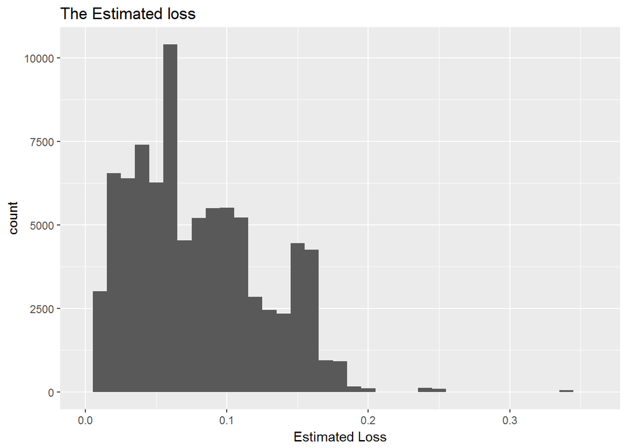

```
##    Min. 1st Qu.  Median    Mean 3rd Qu.    Max.    NA's
##   0.005   0.042   0.072   0.080   0.112   0.366   29084
```

The estimated return assigned to the listing at the time it was created. Estimated return is the difference between the Estimated Effective Yield and the Estimated Loss Rate. Applicable for loans originated after July 2009.

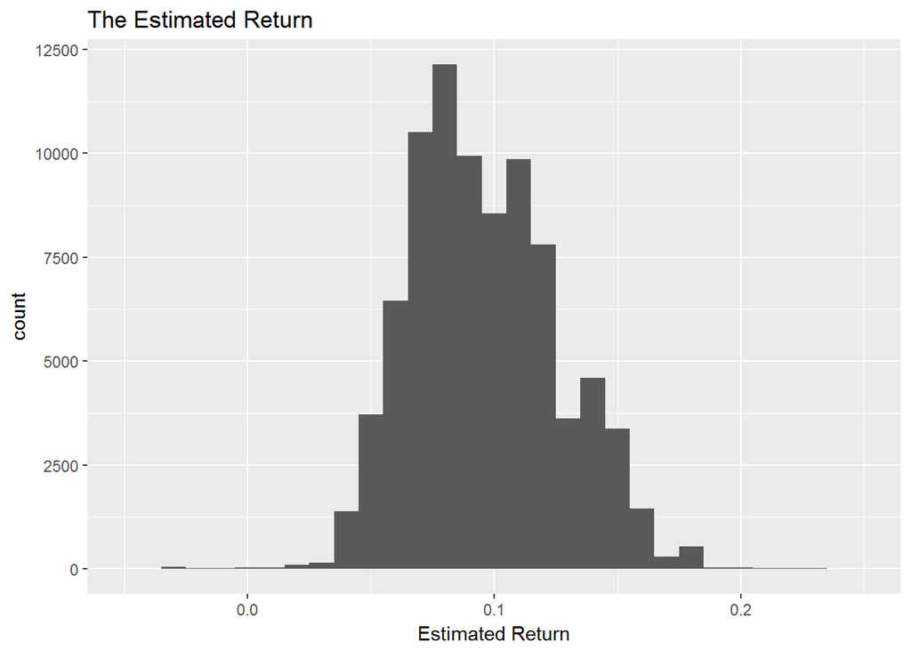

```
##    Min. 1st Qu.  Median    Mean 3rd Qu.    Max.    NA's
##  -0.183   0.074   0.092   0.096   0.117   0.284   29084
```

The income range of the borrower at the time the listing was created.

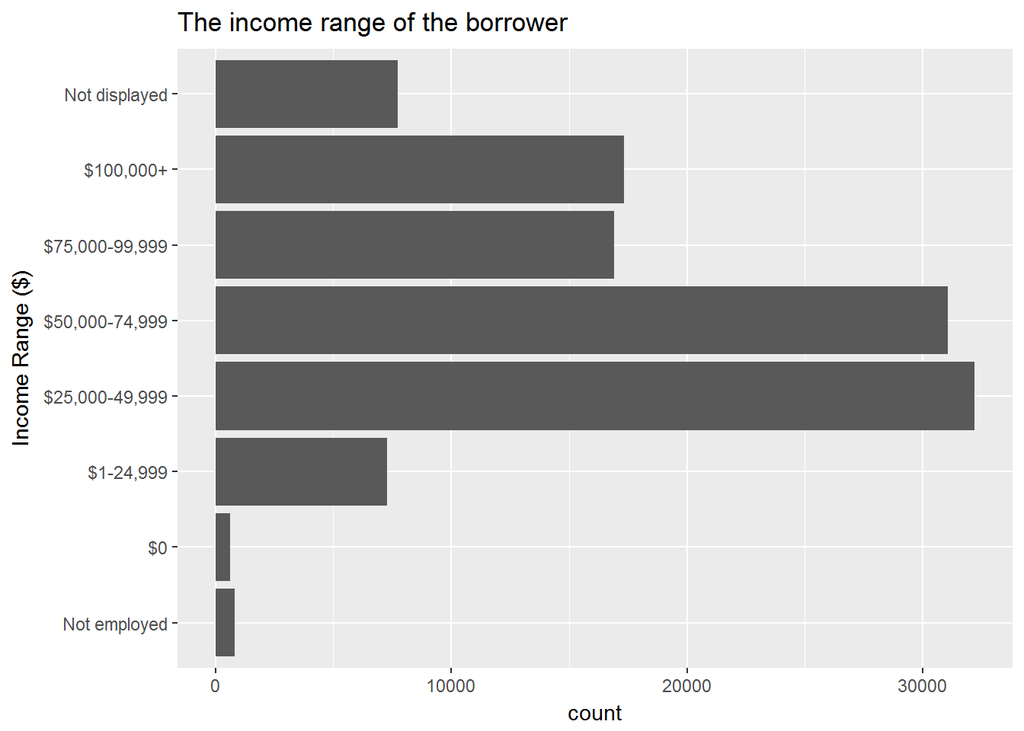

> *Note*: Borrowers income range peaks 25000$ - 74999$ only few are not employed or with 0$ income .

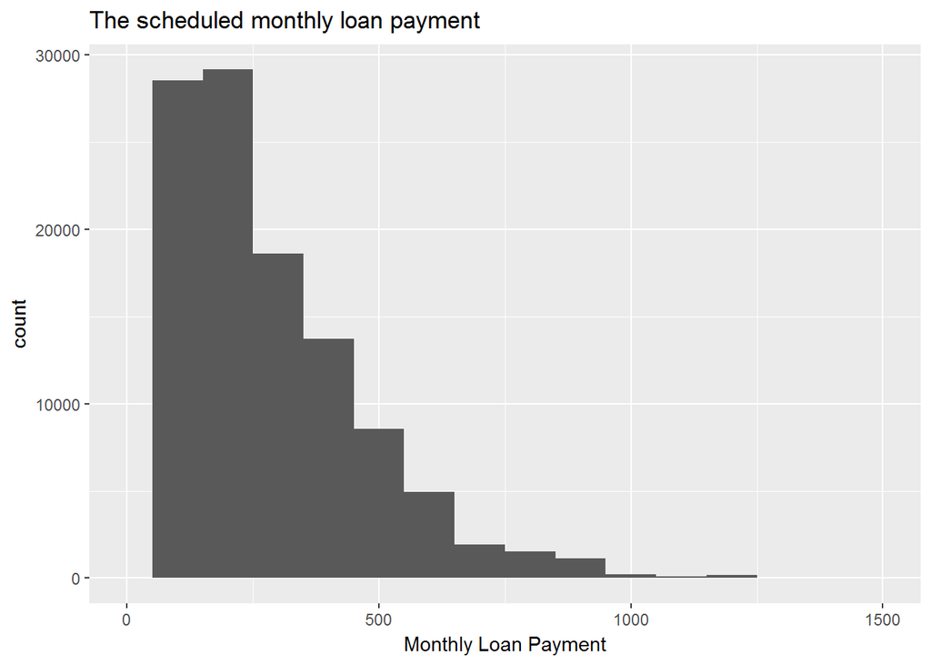

```
##    Min. 1st Qu.  Median    Mean 3rd Qu.    Max.
##     0.0   131.6   217.7   272.5   371.6  2251.5
```

> *Note*: Monthly payment amount is manly lass than 500$ but the plot has long tail in positive direction.

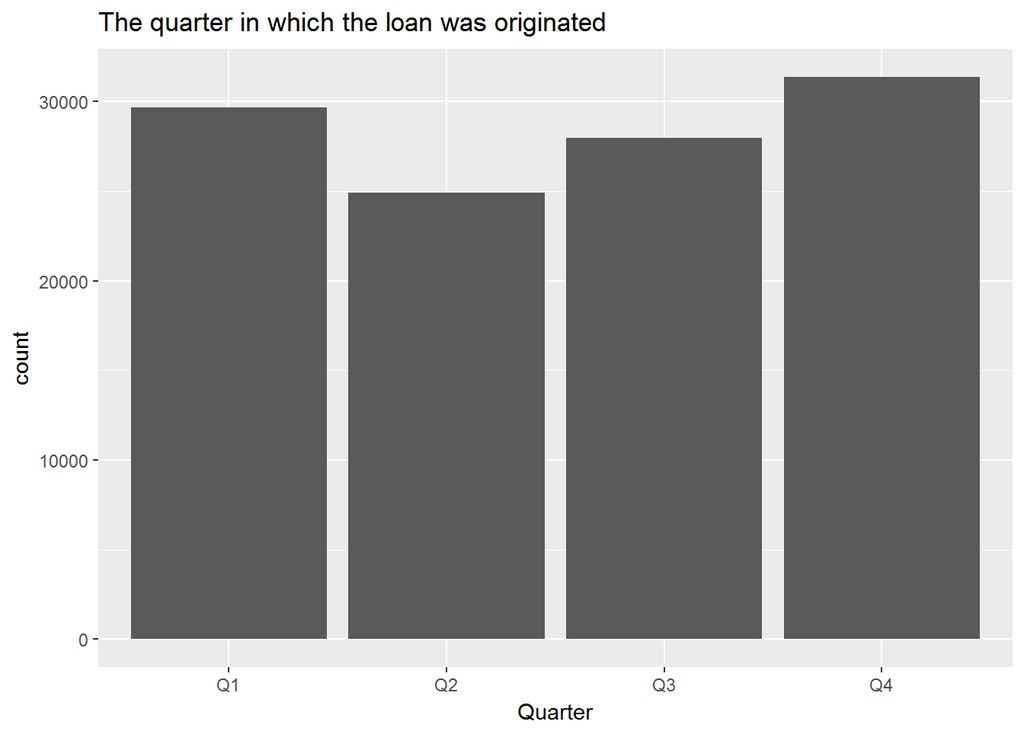

```
##    Length     Class      Mode
##    113937 character character
```

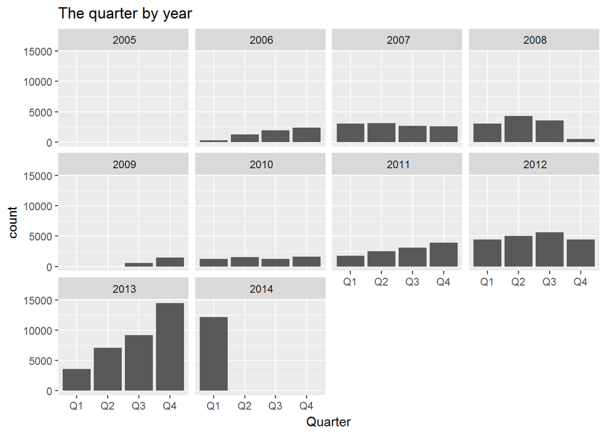

```
## Q1 2006 Q1 2007 Q1 2008 Q1 2010 Q1 2011 Q1 2012 Q1 2013 Q1 2014 Q2 2006
##     315    3079    3074    1243    1744    4435    3616   12172    1254
## Q2 2007 Q2 2008 Q2 2009 Q2 2010 Q2 2011 Q2 2012 Q2 2013 Q3 2006 Q3 2007
##    3118    4344      13    1539    2478    5061    7099    1934    2671
## Q3 2008 Q3 2009 Q3 2010 Q3 2011 Q3 2012 Q3 2013 Q4 2005 Q4 2006 Q4 2007
##    3602     585    1270    3093    5632    9180      22    2403    2592
## Q4 2008 Q4 2009 Q4 2010 Q4 2011 Q4 2012 Q4 2013
##     532    1449    1600    3913    4425   14450
```

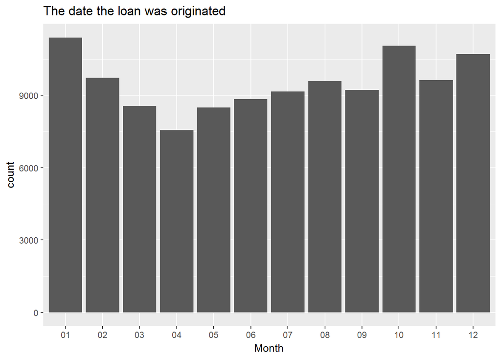

```
##    Length     Class      Mode
##    113937 character character
```

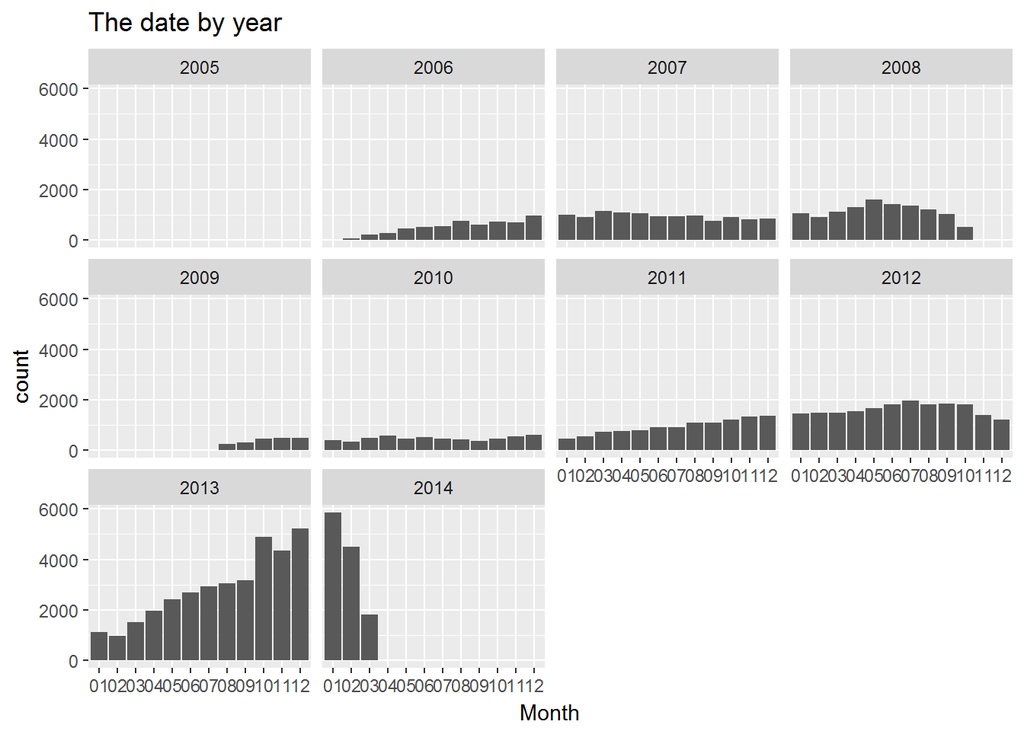

> *Note*: Totally in Q4 is highest number of loans but while looking by year there is different picture. 2013 was the most active year. May be for 2005 and 2014 there we don’t have full information. The information is chacked using variable LoanOriginationDate.

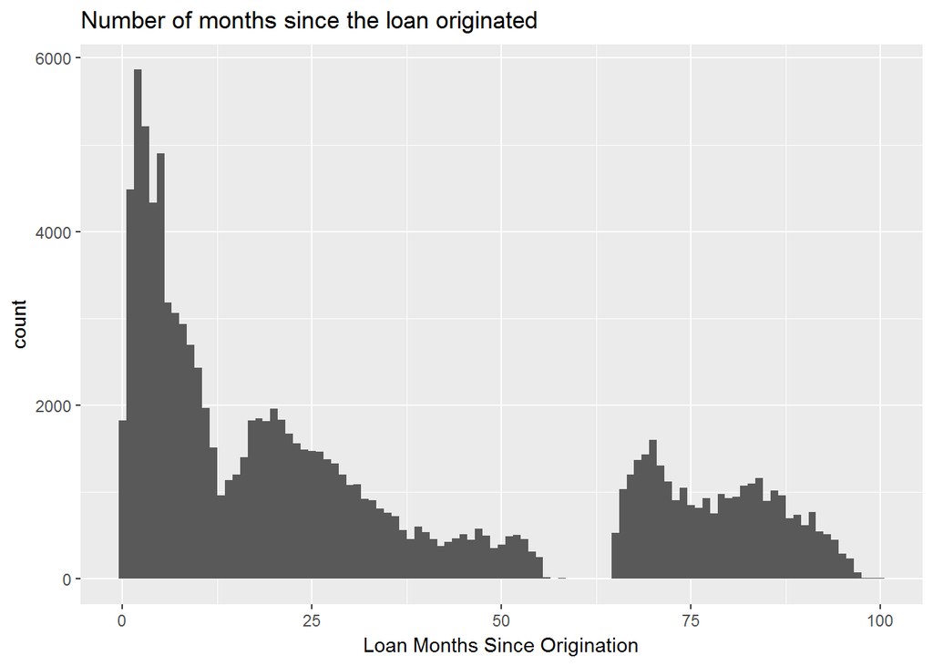

```
##    Min. 1st Qu.  Median    Mean 3rd Qu.    Max.
##     0.0     6.0    21.0    31.9    65.0   100.0
```

> *Note*: The plot peaks around 6 month, other peak is near 24 month there is a gap between 55 and 65 month and other peak is at 69 month.

Number of on time payments the borrower made on Prosper loans at the time they created this listing. This value will be null if the borrower had no prior loans.

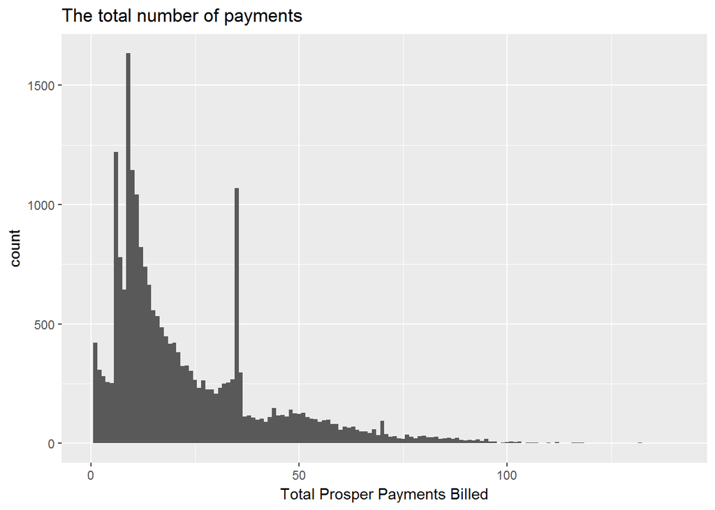

```
##    Min. 1st Qu.  Median    Mean 3rd Qu.    Max.    NA's
##    0.00    9.00   16.00   22.93   33.00  141.00   91852
```

Number of on time payments the borrower had made on Prosper loans at the time they created this listing. This value will be null if the borrower has no prior loans.

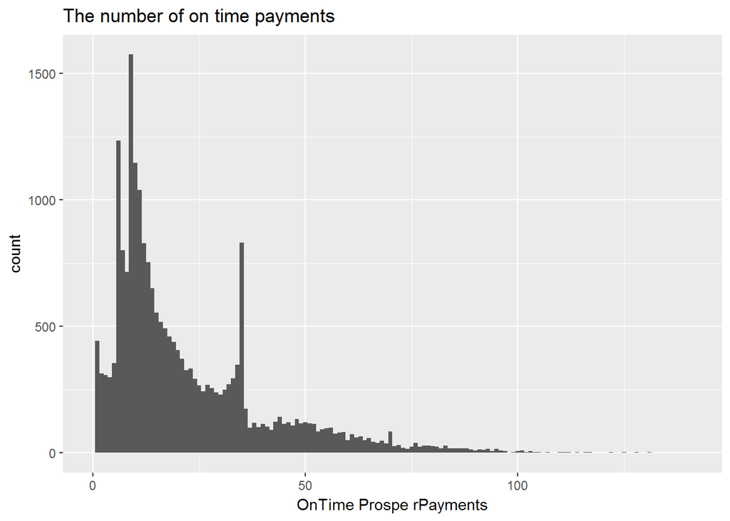

```
##    Min. 1st Qu.  Median    Mean 3rd Qu.    Max.    NA's
##    0.00    9.00   15.00   22.27   32.00  141.00   91852
```

> *Note*: Total and ontime payments not differ much from each other.

# Univariate Analysis

This data set contains 113,937 loans with 81 variables on each loan, including loan amount, borrower rate (or interest rate), current loan status, borrower income, borrower employment status and borrower credit history. Income range, employment status and amount of credit relation are main interest. Monthly payment amount and borrower’s interest rate relaated variables. I have created month, quarter, and year variables from date related variables. I have orderd income range variables from low to high and didn’t take into account NA values.

# Bivariate Plots Section

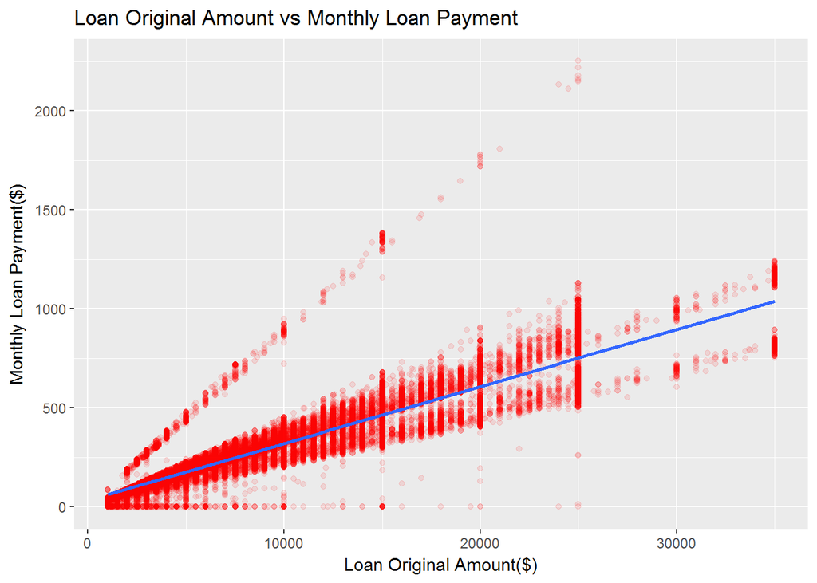

```
##
##  Pearson's product-moment correlation
##
## data:  LoanData$LoanOriginalAmount and LoanData$MonthlyLoanPayment
## t = 867.82, df = 113940, p-value < 2.2e-16
## alternative hypothesis: true correlation is not equal to 0
## 95 percent confidence interval:
##  0.9312165 0.9327426
## sample estimates:
##       cor
## 0.9319837
```

> *Note*: As expected Monthly payment increases when load increases, they are highly correlated.

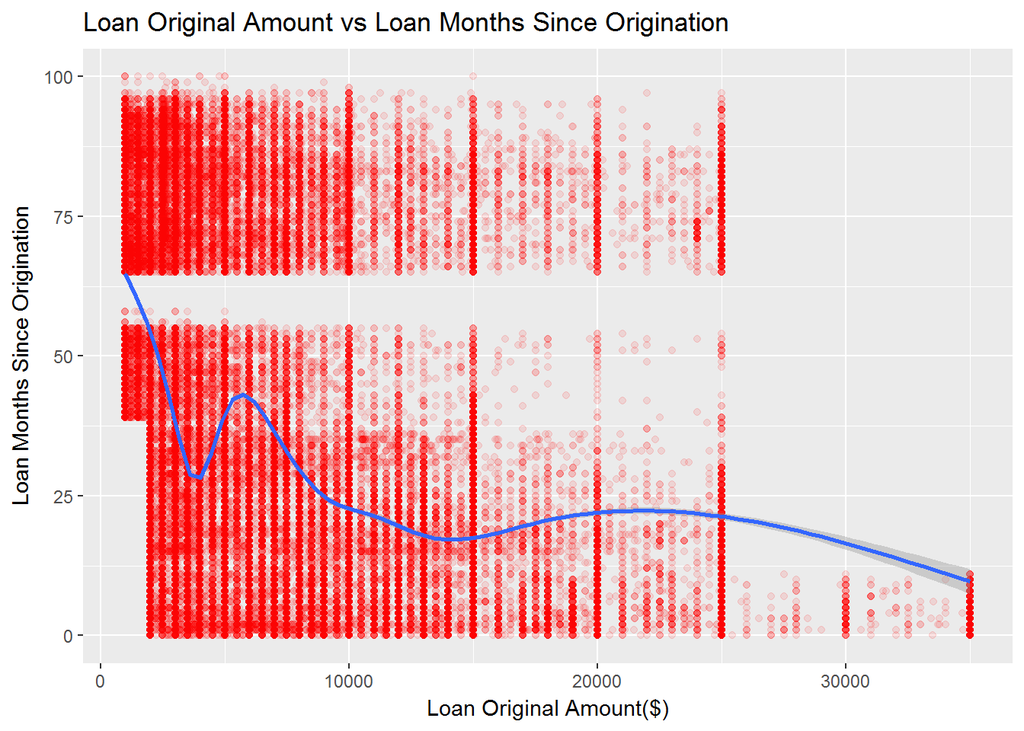

```
##
##  Pearson's product-moment correlation
##
## data:  LoanData$LoanOriginalAmount and LoanData$LoanMonthsSinceOrigination
## t = -109.69, df = 113940, p-value < 2.2e-16
## alternative hypothesis: true correlation is not equal to 0
## 95 percent confidence interval:
##  -0.3143001 -0.3037962
## sample estimates:
##        cor
## -0.3090576
```

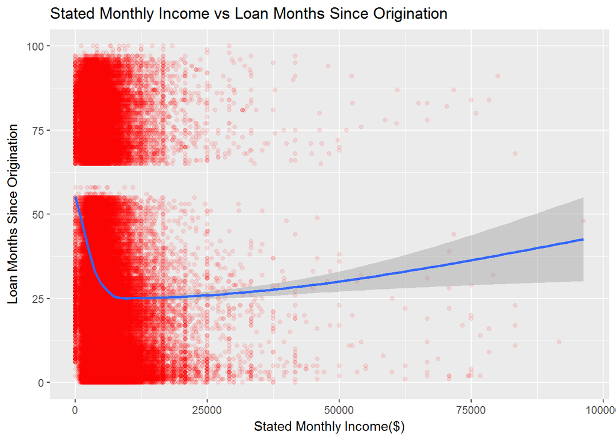

```
##
##  Pearson's product-moment correlation
##
## data:  StatedMonthlyIncome and LoanMonthsSinceOrigination
## t = -54.237, df = 113840, p-value < 2.2e-16
## alternative hypothesis: true correlation is not equal to 0
## 95 percent confidence interval:
##  -0.1643651 -0.1530400
## sample estimates:
##        cor
## -0.1587078
```

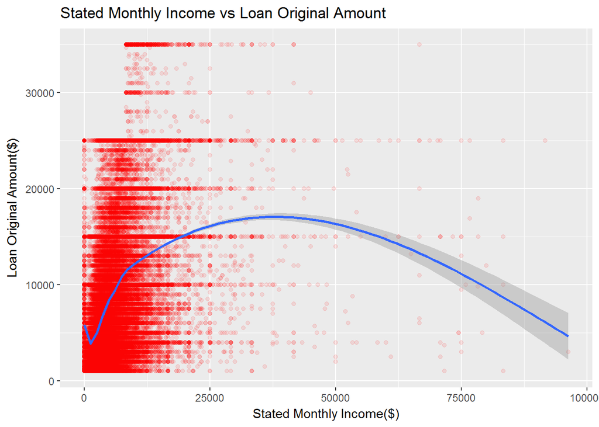

```
##
##  Pearson's product-moment correlation
##
## data:  StatedMonthlyIncome and LoanOriginalAmount
## t = 144.74, df = 113840, p-value < 2.2e-16
## alternative hypothesis: true correlation is not equal to 0
## 95 percent confidence interval:
##  0.3893222 0.3991343
## sample estimates:
##       cor
## 0.3942395
```

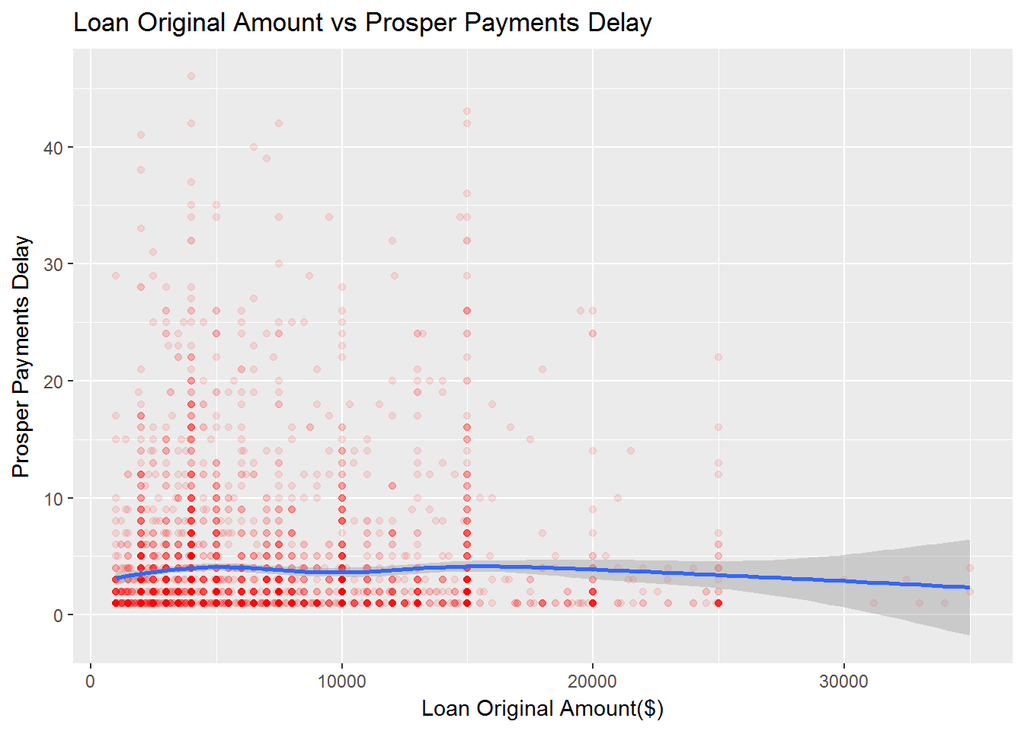

```
##
##  Pearson's product-moment correlation
##
## data:  ProsperPaymentsDelay and LoanOriginalAmount
## t = 0.61246, df = 3802, p-value = 0.5403
## alternative hypothesis: true correlation is not equal to 0
## 95 percent confidence interval:
##  -0.02185450  0.04169909
## sample estimates:
##         cor
## 0.009932328
```

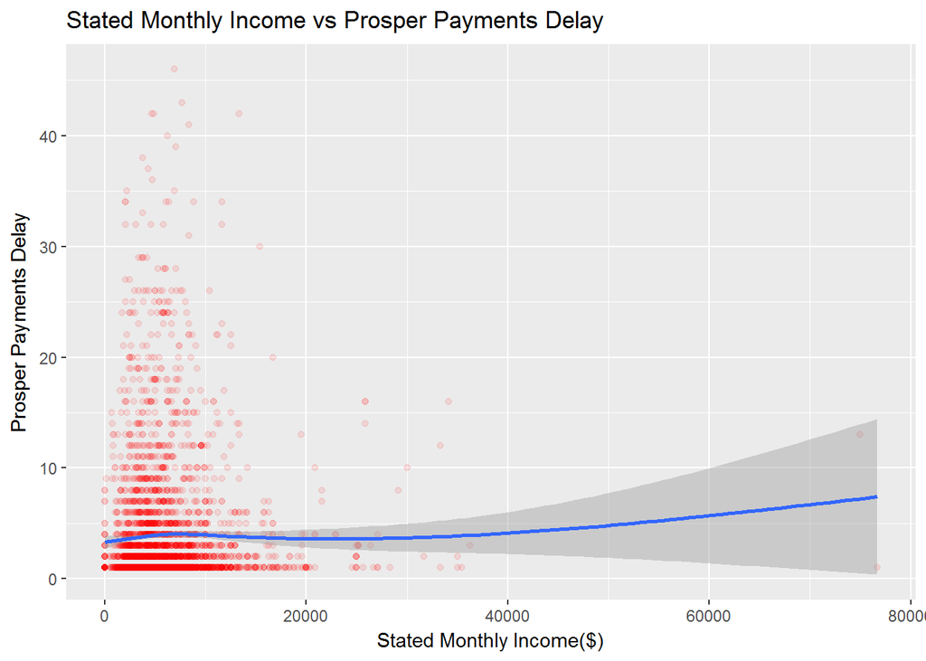

```
##
##  Pearson's product-moment correlation
##
## data:  ProsperPaymentsDelay and StatedMonthlyIncome
## t = 0.9816, df = 3802, p-value = 0.3264
## alternative hypothesis: true correlation is not equal to 0
## 95 percent confidence interval:
##  -0.01587049  0.04767327
## sample estimates:
##        cor
## 0.01591746
```

> *Note*: Loan delay is not depend loan amount. Delay is clustered for monthly income<20000.

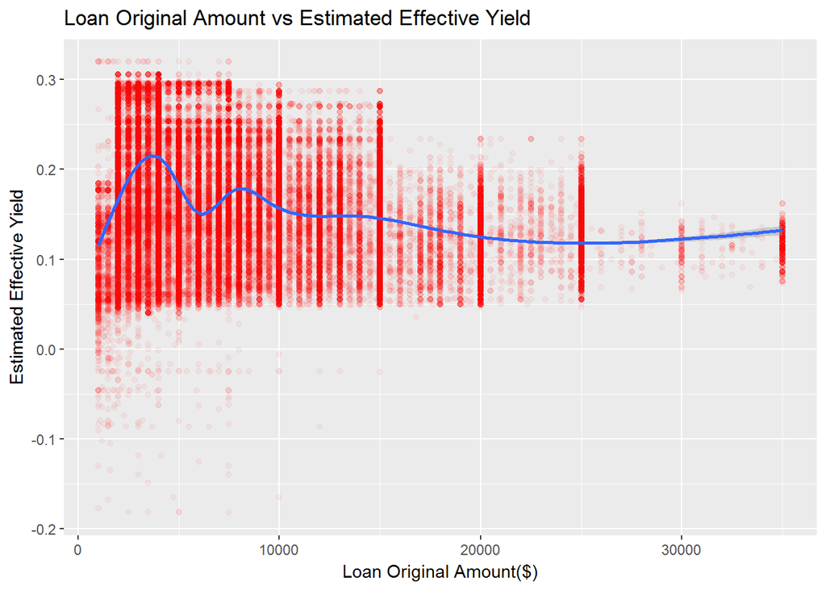

```
##
##  Pearson's product-moment correlation
##
## data:  LoanOriginalAmount and EstimatedEffectiveYield
## t = -100.89, df = 84851, p-value < 2.2e-16
## alternative hypothesis: true correlation is not equal to 0
## 95 percent confidence interval:
##  -0.3332603 -0.3212446
## sample estimates:
##        cor
## -0.3272657
```

> *Note*: EstimatedEffectiveYield and loan amount dependence is visible loans <10000.

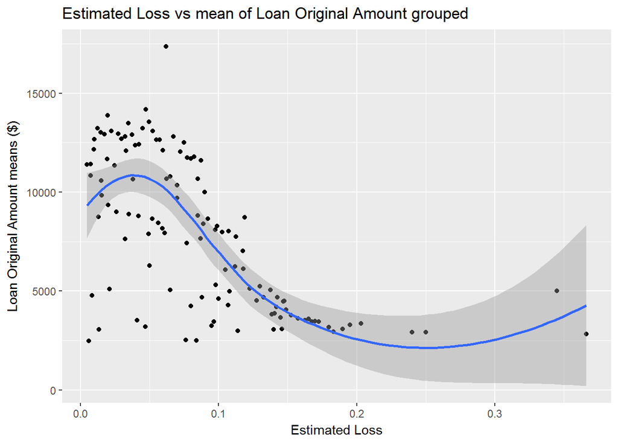

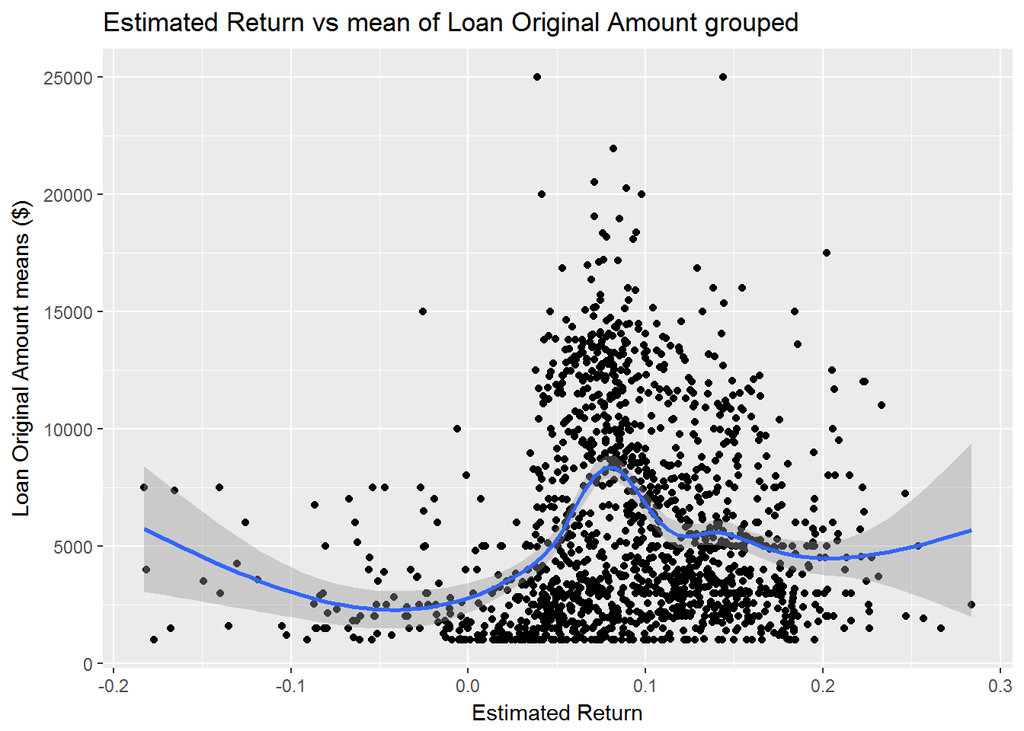

> *Note*: Loan Amount mean is more depend on EstimatedLoss than EstimatedReturn. Manly loss<0,1 is preferable for high amount of loans. Return manly vaies from 0 to 0.2

# Bivariate Analysis

Amount of monly payment increasies proportionally as Loan amount increasies.  
Loan duration decreasies with monthly income increases until it reaches 10000 than dependence dissapiars. High loan amounts have estimated loss less than 0.1. The most delay of payments is observed for incomes less than 10000. LoanOriginalAmount vs MonthlyLoanPayment and OnTimeProsperPayments vs TotalProsperPayments have strongest dependence.

# Multivariate Plots Section

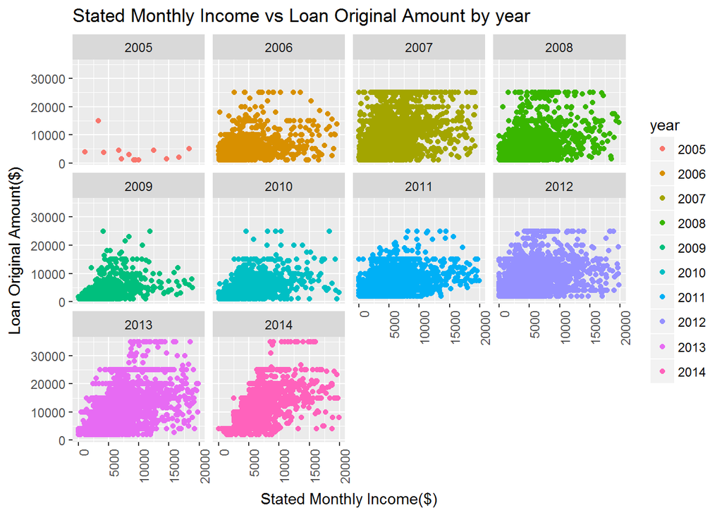

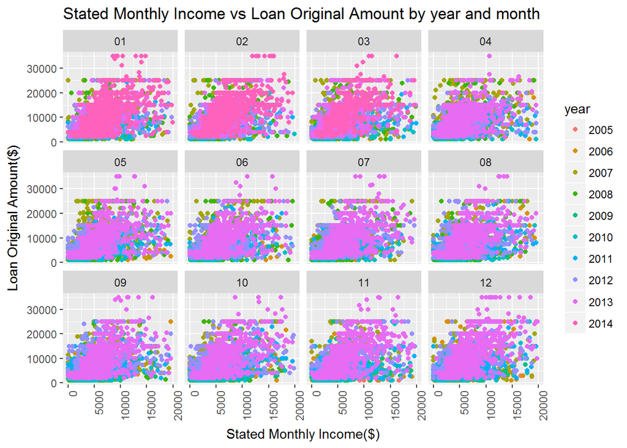

> *Note*: Loan amount increases in 2013 and 2014 with monthly income >8000. Clearly seen that this began in april 2013 and lasts in first quarter of 2014. We have only first quarter information of 2014.

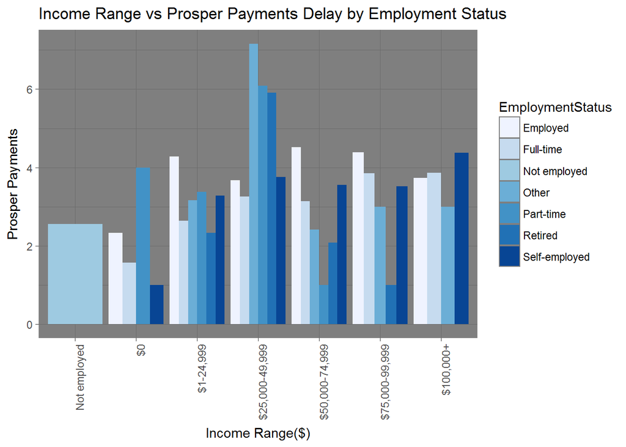

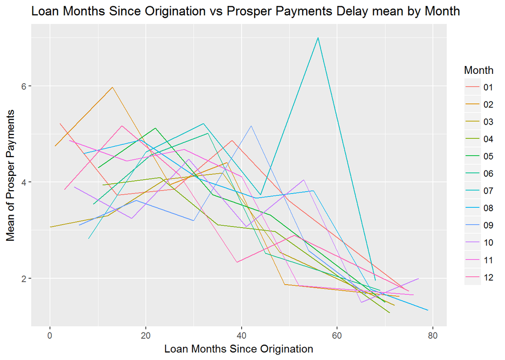

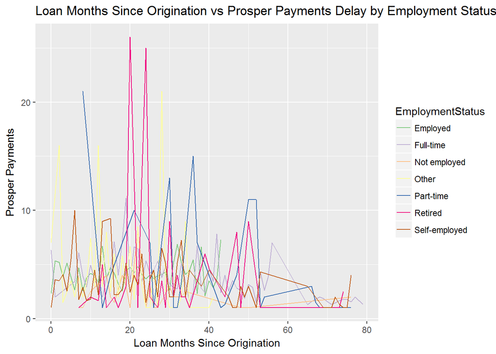

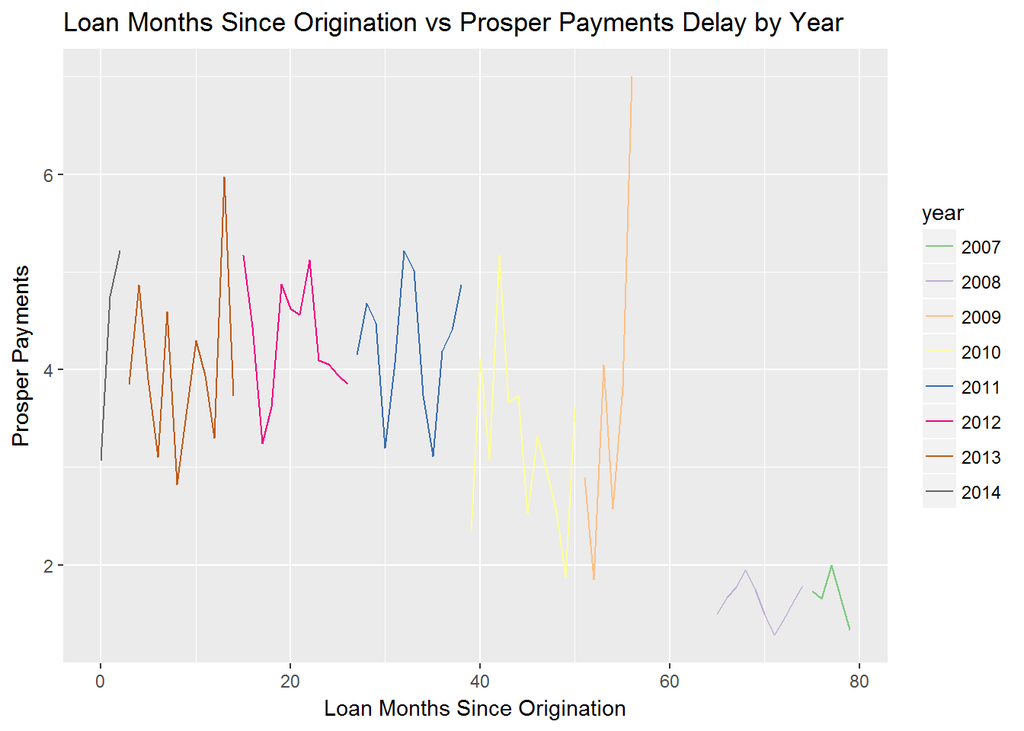

# Multivariate Analysis

# Final Plots and Summary

### Plot One

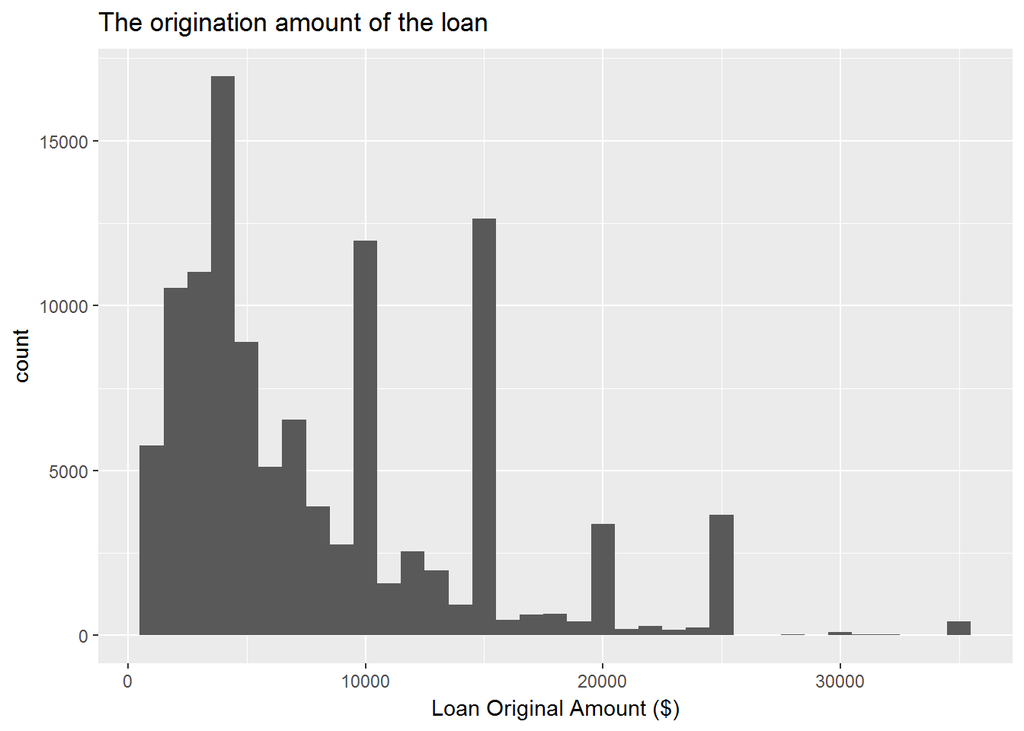

```
##    Min. 1st Qu.  Median    Mean 3rd Qu.    Max.
##    1000    4000    6500    8337   12000   35000
```

### Plot Two

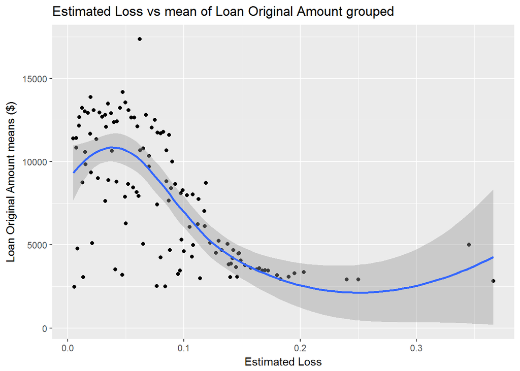